# Pump it Up: Data Mining the Water Table challenge (Top 4%)

Pau Roger Puig-Sureda

# Import Libraries

## Load the previously cleaned dataset

```r
colClasses = c("character","Date","factor","numeric","factor",
               "numeric","numeric","factor","factor","integer","factor","factor",
               "factor","factor","factor","factor",
               "factor","factor","factor","factor","factor","factor",
               "factor","factor","factor","factor","factor","factor",
               "factor","factor")

training_set = read.csv("R_cleaned_training_set.csv", header = TRUE, sep = ",", colClasses = colClasses)
training_labels = read.csv("datasets/Training_set_labels.csv", header = TRUE, sep = ",",  colClasses = c("integer","factor"))
test_set = read.csv("R_cleaned_test_set.csv", header = TRUE, sep = ",", colClasses = colClasses)
```

# Exploring the dataset

Visualize the dataset in order to explore whether the location of the pump has any impact on its state or not.

Plot the pumps in the map of Tanzania.

[figure not shown]

```r
mapImageData <- get_googlemap(center = c(lon = median(training_set$longitude, na.rm = TRUE), lat = median(training_set$latitude, na.rm = TRUE)),
 zoom = 6,
 maptype = c("terrain"))

ggmap(mapImageData, extent = "device") +
 geom_point(aes(x = longitude, y = latitude),
 data = training_set[,c("longitude", "latitude")],
 colour = "red",
 size = 1,
 pch = 20)
```

Plot the state of each pump.

[figure not shown]

```r
train_data <- merge(training_set, training_labels, by="id")
train_data <- train_data[,c("id","longitude","latitude","status_group")]

ggmap(mapImageData) +
 geom_point(aes(x = longitude, y = latitude, colour=status_group),
 data = train_data[,c("longitude", "latitude","status_group")],
 size = 1,
 pch = 20)
```

It seems that there is not any clear relationship between the status of the pumps and their location.

# Feature Engineering

Based on the previous inspection of the dataset, engineer some features to increase the perfomance of the pump status classification.

## Dates

As offered in the dataset they are not very useful. Nevertheless, it offers two interesting aspects about the water pump: how old the measurement is (the older, the less valuable) and in which month it has been recorded (some months might present a more challenging scenario for the pumps.

Transform date_recorded to 3 different features: number of days until Jan 1st 2014, month recorded as factor, and day of the year recorded as numeric.

```r
date_recorded_offset_days <- as.numeric(as.Date("2014-01-01", format="%Y-%m-%d") - as.Date(training_set$date_recorded, format="%d/%m/%y"))
date_recorded_month <- lubridate::month(training_set$date_recorded)
day_of_year <- as.numeric(yday(training_set$date_recorded))
training_set <- training_set[, -which(names(training_set) == "date_recorded")]
training_set <- cbind(training_set, date_recorded_offset_days)
training_set <- cbind(training_set, date_recorded_month)
training_set <- cbind(training_set, day_of_year)

date_recorded_offset_days <- as.numeric(as.Date("2014-01-01", format="%Y-%m-%d") - as.Date(test_set$date_recorded, format="%d/%m/%y"))
date_recorded_month <- lubridate::month(test_set$date_recorded)
day_of_year <- as.numeric(yday(test_set$date_recorded))
test_set <- test_set[, -which(names(test_set) == "date_recorded")]
test_set <- cbind(test_set, date_recorded_offset_days)
test_set <- cbind(test_set, date_recorded_month)
test_set <- cbind(test_set, day_of_year)
```

Some features that are subclasses of other features: `extraction_type_class`, `extraction_type_group` and `extraction_type`. Let’s inspect their values to decide whether makes sense to keep them unmodified, to combine them, or to only select some of them.

```r
tally(group_by(training_set, extraction_type_class, extraction_type_group, extraction_type))
```

```
## # A tibble: 18 x 4
## # Groups:   extraction_type_class, extraction_type_group [?]
##    extraction_type_class extraction_type_group extraction_type       n
##    <fct>                 <fct>                 <fct>             <int>
##  1 gravity               gravity               gravity           26780
##  2 handpump              afridev               afridev            1770
##  3 handpump              india mark ii         india mark ii      2400
##  4 handpump              india mark iii        india mark iii       98
##  5 handpump              nira/tanira           nira/tanira        8154
##  6 handpump              other handpump        other                 2
##  7 handpump              other handpump        other - play pump    85
##  8 handpump              other handpump        other - swn 81      229
##  9 handpump              other handpump        walimi               48
## 10 handpump              swn 80                swn 80             3670
## 11 motorpump             mono                  mono               2865
## 12 motorpump             other motorpump       cemo                 90
## 13 motorpump             other motorpump       climax               32
## 14 other                 other                 other              6430
## 15 rope pump             rope pump             other - rope pump   451
## 16 submersible           submersible           ksb                1415
## 17 submersible           submersible           submersible        4764
## 18 wind-powered          wind-powered          windmill            117
```

The middle level, `extraction_type_group`, does not provide much information than the other two levels. Therefore, we remove it. We also combine some of the smaller levels which does not provide useful information (i.e. india mark ii and india mark iii).

```r
training_set <- mutate(training_set, extraction_type = revalue(extraction_type,
                                                               c("cemo" = "other motorpump",
                                                                   "climax" = "other motorpump",
                                                                   "other - play pump" = "other handpump",
                                                                   "walimi" = "other handpump",
                                                                   "other - swn 81" = "swn",
                                                                   "swn 80" = "swn",
                                                                   "india mark ii" = "india mark",
                                                                   "india mark iii" = "india mark")))

training_set <- training_set[, -which(names(training_set) == "extraction_type_group")]

test_set <- mutate(test_set, extraction_type = revalue(extraction_type,
                                                               c("cemo" = "other motorpump",
                                                                   "climax" = "other motorpump",
                                                                   "other - play pump" = "other handpump",
                                                                   "walimi" = "other handpump",
                                                                   "other - swn 81" = "swn",
                                                                   "swn 80" = "swn",
                                                                   "india mark ii" = "india mark",
                                                                   "india mark iii" = "india mark")))

test_set <- test_set[, -which(names(test_set) == "extraction_type_group")]
```

In a similar way, `source`, `source_type` and `source_class` provide hiearchical information of the same aspect. We remove the middle level `source_type`.

```r
tally(group_by(training_set, source, source_type, source_class))
```

```
## # A tibble: 10 x 4
## # Groups:   source, source_type [?]
##    source               source_type          source_class     n
##    <fct>                <fct>                <fct>        <int>
##  1 dam                  dam                  surface        656
##  2 hand dtw             borehole             groundwater    874
##  3 lake                 river/lake           surface        765
##  4 machine dbh          borehole             groundwater  11075
##  5 other                other                unknown        212
##  6 rainwater harvesting rainwater harvesting surface       2295
##  7 river                river/lake           surface       9612
##  8 shallow well         shallow well         groundwater  16824
##  9 spring               spring               groundwater  17021
## 10 unknown              other                unknown         66
```

```r
training_set <- training_set[, -which(names(training_set) == "source_type")]
test_set <- test_set[, -which(names(test_set) == "source_type")]
```

Insepcting the `payment` and `payment_type` features, we can see that they share the same information (although some categories have been renamed). We keep `payment_type`.

```r
tally(group_by(training_set, payment_type, payment))
```

```
## # A tibble: 7 x 3
## # Groups:   payment_type [?]
##   payment_type payment                   n
##   <fct>        <fct>                 <int>
## 1 annually     pay annually           3642
## 2 monthly      pay monthly            8300
## 3 never pay    never pay             25348
## 4 on failure   pay when scheme fails  3914
## 5 other        other                  1054
## 6 per bucket   pay per bucket         8985
## 7 unknown      unknown                8157
```

```r
training_set <- training_set[, -which(names(training_set) == "payment")]
test_set <- test_set[, -which(names(test_set) == "payment")]
```

The `quality_group` and the `water_quality` features have similar information. We keep the more specific `water_quality`.

```r
tally(group_by(training_set, quality_group, water_quality))
```

```
## # A tibble: 8 x 3
## # Groups:   quality_group [?]
##   quality_group water_quality          n
##   <fct>         <fct>              <int>
## 1 colored       coloured             490
## 2 fluoride      fluoride             200
## 3 fluoride      fluoride abandoned    17
## 4 good          soft               50818
## 5 milky         milky                804
## 6 salty         salty               4856
## 7 salty         salty abandoned      339
## 8 unknown       unknown             1876
```

```r
training_set <- training_set[, -which(names(training_set) == "quality_group")]
test_set <- test_set[, -which(names(test_set) == "quality_group")]
```

Similarly, we keep the feature `waterpoint_type`, more precise than `waterpoint_type_group`.

```r
tally(group_by(training_set, waterpoint_type_group, waterpoint_type))
```

```
## # A tibble: 7 x 3
## # Groups:   waterpoint_type_group [?]
##   waterpoint_type_group waterpoint_type                 n
##   <fct>                 <fct>                       <int>
## 1 cattle trough         cattle trough                 116
## 2 communal standpipe    communal standpipe          28522
## 3 communal standpipe    communal standpipe multiple  6103
## 4 dam                   dam                             7
## 5 hand pump             hand pump                   17488
## 6 improved spring       improved spring               784
## 7 other                 other                        6380
```

```r
training_set <- training_set[, -which(names(training_set) == "waterpoint_type_group")]
test_set <- test_set[, -which(names(test_set) == "waterpoint_type_group")]
```

Given that the features `quantity` y `quantity_group` have exactly the same information, we only keep `quantity`.

```r
tally(group_by(training_set, quantity, quantity_group))
```

```
## # A tibble: 5 x 3
## # Groups:   quantity [?]
##   quantity     quantity_group     n
##   <fct>        <fct>          <int>
## 1 dry          dry             6246
## 2 enough       enough         33186
## 3 insufficient insufficient   15129
## 4 seasonal     seasonal        4050
## 5 unknown      unknown          789
```

```r
training_set <- training_set[, -which(names(training_set) == "quantity_group")]
test_set <- test_set[, -which(names(test_set) == "quantity_group")]
```

From [Expert Africa](https://www.expertafrica.com/tanzania/info/tanzania-weather-and-climate): *Tanzania has two rainy seasons: The short rains from late-October to late-December, a.k.a. the Mango Rains and the long rains from March to May*. Therefore, we are going to create this `season` variable.

```r
training_set <- mutate(training_set, season = factor( ifelse( date_recorded_month <= 2, "dry short",
                                                              ifelse( date_recorded_month <= 5, "wet long",
                                                                      ifelse(date_recorded_month <= 9, "dry long", "wet short")))))

test_set <- mutate(test_set, season = factor( ifelse( date_recorded_month <= 2, "dry short",
                                                      ifelse( date_recorded_month <= 5, "wet long",
                                                              ifelse(date_recorded_month <= 9, "dry long", "wet short")))))

summary(training_set)
```

```
##       id                               funder        gps_height
##  Length:59400       Government Of Tanzania: 9084   Min.   : -90.0
##  Class :character                         : 3635   1st Qu.:   0.0
##  Mode  :character   Danida                : 3114   Median : 369.0
##                     Hesawa                : 2202   Mean   : 668.3
##                     Rwssp                 : 1374   3rd Qu.:1319.2
##                     World Bank            : 1349   Max.   :2770.0
##                     (Other)               :38642
##       installer       longitude        latitude
##  DWE       :17402   Min.   :29.61   Min.   :-11.6494
##            : 3655   1st Qu.:33.23   1st Qu.: -8.5406
##  Government: 1825   Median :34.91   Median : -5.0216
##  RWE       : 1206   Mean   :35.09   Mean   : -5.7796
##  Commu     : 1060   3rd Qu.:37.18   3rd Qu.: -3.3262
##  DANIDA    : 1050   Max.   :40.35   Max.   : -0.9985
##  (Other)   :33202
##              basin               region        population
##  Lake Victoria  :10248   Iringa     : 5294   Min.   :    1.0
##  Pangani        : 8940   Shinyanga  : 4982   1st Qu.:  100.0
##  Rufiji         : 7976   Mbeya      : 4639   Median :  281.0
##  Internal       : 7785   Kilimanjaro: 4379   Mean   :  281.1
##  Lake Tanganyika: 6432   Morogoro   : 4006   3rd Qu.:  281.0
##  Wami / Ruvu    : 5987   Arusha     : 3350   Max.   :30500.0
##  (Other)        :12032   (Other)    :32750
##  public_meeting        scheme_management     permit      construction_year
##  FALSE  : 5055   VWC            :36793   FALSE  :17492   2010   : 2645
##  TRUE   :51011   WUG            : 5206   TRUE   :38852   2008   : 2613
##  unknown: 3334                  : 3878   unknown: 3056   2009   : 2533
##                  Water authority: 3153                   2000   : 2091
##                  WUA            : 2883                   2007   : 1587
##                  Water Board    : 2748                   (Other):27222
##                  (Other)        : 4739                   NA's   :20709
##     extraction_type   extraction_type_class            management
##  gravity    :26780   gravity     :26780     vwc             :40507
##  nira/tanira: 8154   handpump    :16456     wug             : 6515
##  other      : 6432   motorpump   : 2987     water board     : 2933
##  submersible: 4764   other       : 6430     wua             : 2535
##  swn        : 3899   rope pump   :  451     private operator: 1971
##  mono       : 2865   submersible : 6179     parastatal      : 1768
##  (Other)    : 6506   wind-powered:  117     (Other)         : 3171
```

[output cut: 17 more lines]

```
##  cattle trough              :  116   Min.   :  29.0
##  communal standpipe         :28522   1st Qu.: 326.0
##  communal standpipe multiple: 6103   Median : 448.0
##  dam                        :    7   Mean   : 642.6
##  hand pump                  :17488   3rd Qu.:1006.0
##  improved spring            :  784   Max.   :4097.0
##  other                      : 6380
##  date_recorded_month  day_of_year          season
##  Min.   : 1.000      Min.   :  1.0   dry long :10966
##  1st Qu.: 2.000      1st Qu.: 53.0   dry short:18756
##  Median : 3.000      Median : 78.0   wet long :22242
##  Mean   : 4.376      Mean   :117.6   wet short: 7436
##  3rd Qu.: 7.000      3rd Qu.:199.0
##  Max.   :12.000      Max.   :359.0
##
```

The feature `construction_year` a priori seems to be one of the most important ones: the older the pump, the more probable its failure. The following figure shows the impact of this feature on the pump status.

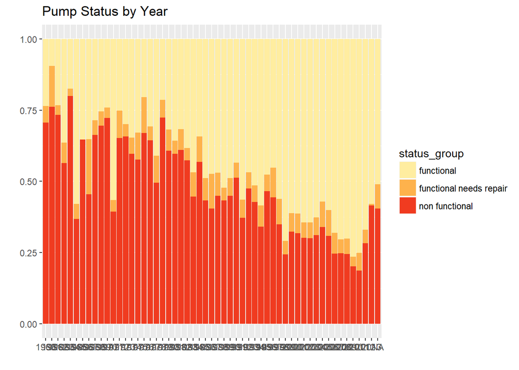

```r
train_data <- merge(training_set,training_labels, by="id")

ggplot(data = train_data, aes(x = construction_year)) +
  geom_bar(aes (fill=status_group), position = "fill") +
  xlab('')+ylab('') +
  ggtitle('Pump Status by Year') +
  scale_fill_brewer(palette="YlOrRd")
```

In order to increase the predictive power of the feature, we convert it to a factor and reduce the factor levels to 20.

```r
NUM_LEVELS_CONSTRUCTION_YEAR = 20
training_set$construction_year <- factor(paste0("y",as.character(training_set$construction_year)))
cyears <- names(summary(training_set$construction_year)[order(-summary(training_set$construction_year))][1:NUM_LEVELS_CONSTRUCTION_YEAR])
cy <- factor(training_set$construction_year, levels=c(cyears, "Other"))
cy[is.na(cy)] <- "Other"
training_set$construction_year <- cy

test_set$construction_year <- factor(paste0("y",as.character(test_set$construction_year)))
cy <- factor(test_set$construction_year, levels=c(cyears, "Other"))
cy[is.na(cy)] <- "Other"
test_set$construction_year <- cy
```

The organization funding the pumps might have a great impact in their performance as well. Local authorities, closer to the communities, are expected to have better knowledge of the specific logistics and the actual need from the people. Consequently, the pumps funded by these local authorities should perform better. In this sense, we are going to create a new feature `funder_cat` that groups the funder in 5 categories (local_community, Tanzania_Gov, foreign_gov, UN_agencies and others).

```r
fun<-as.character(training_set$funder)

f_gov<-c('danida', 'A/co germany', 'belgian', 'british', 'england', 'german', 'germany',
         'china', 'egypt', 'European Union', 'finland', 'japan', 'france', 'greec',
         'netherlands', 'holland', 'holand', 'nethe', 'nethalan', 'netherla', 'netherlands',
         'iran', 'irish', 'islam','italy', 'U.S.A', 'usa', 'usaid', 'swiss', 'swedish','korea', 'niger')
NGO<-c('World Bank', 'Ngo', "Ngos", "Un","Un Habitat", "Un/wfp", "Undp", "Undp/aict", "Undp/ilo", "Unesco",
       "Unhcr", "Unhcr/government", "Unice", "Unice/ Cspd", "Unicef", "Unicef/ Csp", "Unicef/african Muslim Agency",
       "Unicef/central", "Unicef/cspd", "Uniceg", "Unicet", "Unicrf", "Uniseg", "Unp/aict", "wwf", "wfp")
local_commu <- unique(c(agrep('commu', training_set$funder, value=TRUE),
                        agrep('vill', training_set$funder, value=TRUE)))
tanz_gov<- unique(c(agrep('Government of Tanzania', training_set$funder, value=TRUE),
                    agrep('wsdp', training_set$funder, value=TRUE)))
unique(fun[agrep('wsdp', fun)])
```

```
##  [1] "Dwsp"            "Rwssp"           "Dsdp"
##  [4] "Wsdp"            "Dwssp"           "Wsdp & Sdg"
##  [7] "Rwsp"            "Asdp"            "Ded/rwssp"
## [10] "Rwssp/wsdp"      "Nwssp"           "Nrwssp"
## [13] "Dwsdp"           "Rwssp Shinyanga" "Drwssp"
## [16] "Ded_rwsp"
```

```r
training_set$funder = as.character(training_set$funder)
temp = training_set$funder

for (i in 1:length(NGO)){
  temp = replace(temp,
                 agrep(NGO[i], temp),
                 'UN_agencies')
}

for (i in 1:length(f_gov)){
  temp = replace(temp,
                 agrep(f_gov[i], temp),
                 'foreign_gov')
}

for (i in 1:length(local_commu)){
  temp = replace(temp,
                 agrep(local_commu[i], temp),
                 "local_community")
}

for (i in 1:length(tanz_gov)){
  temp = replace(temp,
                 agrep(tanz_gov[i], temp),
                 "Tanzania_Gov")
}

temp = replace(temp,
               temp != "UN_agencies" & temp != 'foreign_gov' & temp != 'local_community' & temp != 'Tanzania_Gov',
               'other')

training_set$funder_cat<-factor(temp)

test_set$funder = as.character(test_set$funder)

temp = test_set$funder

for (i in 1:length(NGO)){
  temp = replace(temp,
                 agrep(NGO[i], temp),
                 'UN_agencies')
}

for (i in 1:length(f_gov)){
  temp = replace(temp,
                 agrep(f_gov[i], temp),
                 'foreign_gov')
}

for (i in 1:length(local_commu)){
  temp = replace(temp,
                 agrep(local_commu[i], temp),
                 "local_community")
}

for (i in 1:length(tanz_gov)){
  temp = replace(temp,
                 agrep(tanz_gov[i], temp),
                 "Tanzania_Gov")
}

temp = replace(temp,
               temp != "UN_agencies" & temp != 'foreign_gov' & temp != 'local_community' & temp != 'Tanzania_Gov',
               'other')

test_set$funder_cat<-factor(temp)

training_set$funder = factor(training_set$funder)
test_set$funder = factor(test_set$funder)
```

As seen in the following figure, our assumption is confirmed. The more ‘local’ the funder, the better the performance of the pump.

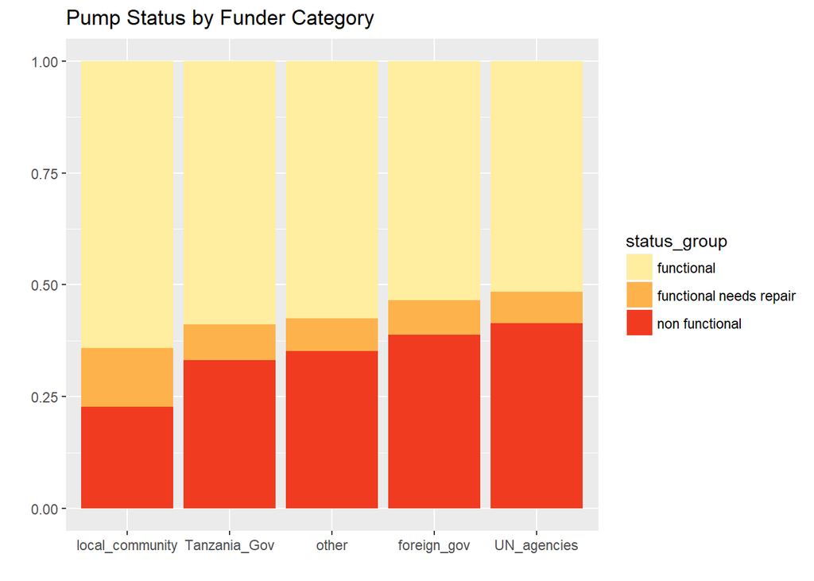

```r
train_data <- merge(training_set,training_labels, by="id")

position <- c("local_community", "Tanzania_Gov", "other", "foreign_gov", "UN_agencies")
ggplot(data = train_data, aes(x=funder_cat)) +
  geom_bar(aes(fill = status_group), position = "fill") +
  scale_x_discrete(limits = position) +
  xlab('') + ylab('') +
  ggtitle('Pump Status by Funder Category') +
  scale_fill_brewer(palette="YlOrRd")
```

Inspecting the funder column in more detail, it has hundreds, even thousands of values. However, many of the funders has very few pumps associated.

```r
#Number of factors in the original funder data
print(nlevels(training_set$funder))
```

```
## [1] 1898
```

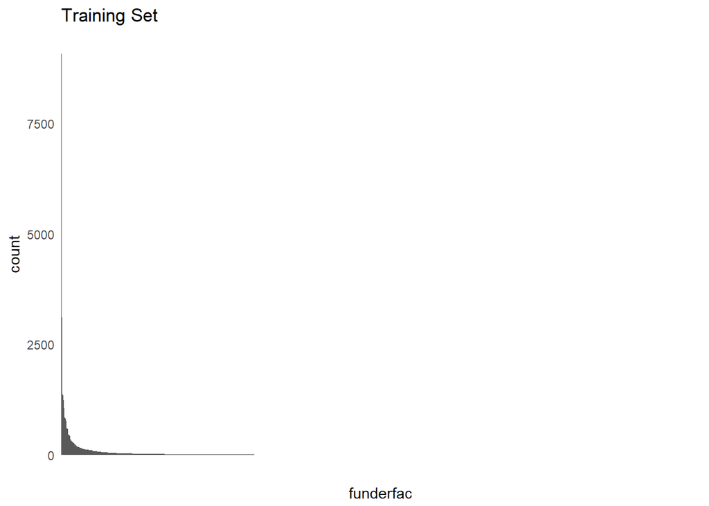

```r
#Histogram of the original funder data
tb <- table(training_set$funder)
funderfac <- factor(training_set$funder, levels = names(tb[order(tb, decreasing = TRUE)]))
qplot(funderfac, main = "Training Set") + theme(axis.text.x = element_blank(), axis.ticks = element_blank())
```

```r
#Number of factors in the original funder data
print(nlevels(test_set$funder))
```

```
## [1] 981
```

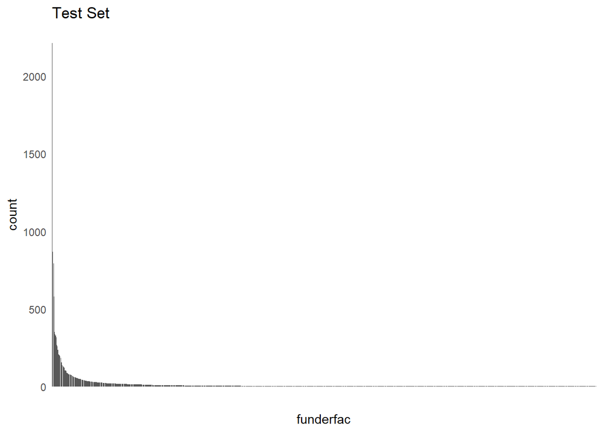

```r
#Histogram of the original funder data
tb <- table(test_set$funder)
funderfac <- factor(test_set$funder, levels = names(tb[order(tb, decreasing = TRUE)]))
qplot(funderfac, main = "Test Set") + theme(axis.text.x = element_blank(), axis.ticks = element_blank())
```

We are going to take only the most important and leave the rest as “Other”.

```r
NUM_LEVELS_FUNDER = 15

funderNames <- names(summary(training_set$funder)[1:NUM_LEVELS_FUNDER])
funder <- factor(training_set$funder, levels=c(funderNames, "Other"))
funder[is.na(funder)] <- "Other"
training_set$funder <- funder

funder <- factor(test_set$funder, levels=c(funderNames, "Other"))
funder[is.na(funder)] <- "Other"
test_set$funder <- funder
```

Same logic is applied to the Installer column: take only the most important features and leave the rest as “Other”.

```r
NUM_LEVELS_INSTALLER = 15
installerNames <- names(summary(training_set$installer)[1:NUM_LEVELS_INSTALLER])
installer <- factor(training_set$installer, levels=c(installerNames, "Other"))
installer[is.na(installer)] <- "Other"
training_set$installer <- installer

installer <- factor(test_set$installer, levels=c(installerNames, "Other"))
installer[is.na(installer)] <- "Other"
test_set$installer <- installer
```

Check that there is no more NA values in the dataset.

```r
sapply(training_set, function(x) sum(is.na(x)))
```

```
##                        id                    funder
##                         0                         0
##                gps_height                 installer
##                         0                         0
##                 longitude                  latitude
##                         0                         0
##                     basin                    region
##                         0                         0
##                population            public_meeting
##                         0                         0
##         scheme_management                    permit
##                         0                         0
##         construction_year           extraction_type
##                         0                         0
##     extraction_type_class                management
##                         0                         0
##          management_group              payment_type
##                         0                         0
##             water_quality                  quantity
##                         0                         0
##                    source              source_class
##                         0                         0
##           waterpoint_type date_recorded_offset_days
##                         0                         0
##       date_recorded_month               day_of_year
##                         0                         0
##                    season                funder_cat
##                         0                         0
```

## Saving the feature engineered dataset

```r
summary(training_set)
```

```
##       id                               funder        gps_height
##  Length:59400       Other                 :30089   Min.   : -90.0
##  Class :character   Government Of Tanzania: 9084   1st Qu.:   0.0
##  Mode  :character                         : 3635   Median : 369.0
##                     Danida                : 3114   Mean   : 668.3
##                     Hesawa                : 2202   3rd Qu.:1319.2
##                     Rwssp                 : 1374   Max.   :2770.0
##                     (Other)               : 9902
##       installer       longitude        latitude
##  Other     :27092   Min.   :29.61   Min.   :-11.6494
##  DWE       :17402   1st Qu.:33.23   1st Qu.: -8.5406
##            : 3655   Median :34.91   Median : -5.0216
##  Government: 1825   Mean   :35.09   Mean   : -5.7796
##  RWE       : 1206   3rd Qu.:37.18   3rd Qu.: -3.3262
##  Commu     : 1060   Max.   :40.35   Max.   : -0.9985
##  (Other)   : 7160
##              basin               region        population
##  Lake Victoria  :10248   Iringa     : 5294   Min.   :    1.0
##  Pangani        : 8940   Shinyanga  : 4982   1st Qu.:  100.0
##  Rufiji         : 7976   Mbeya      : 4639   Median :  281.0
##  Internal       : 7785   Kilimanjaro: 4379   Mean   :  281.1
##  Lake Tanganyika: 6432   Morogoro   : 4006   3rd Qu.:  281.0
##  Wami / Ruvu    : 5987   Arusha     : 3350   Max.   :30500.0
##  (Other)        :12032   (Other)    :32750
##  public_meeting        scheme_management     permit      construction_year
##  FALSE  : 5055   VWC            :36793   FALSE  :17492   yNA    :20709
##  TRUE   :51011   WUG            : 5206   TRUE   :38852   Other  :12210
##  unknown: 3334                  : 3878   unknown: 3056   y2010  : 2645
##                  Water authority: 3153                   y2008  : 2613
##                  WUA            : 2883                   y2009  : 2533
##                  Water Board    : 2748                   y2000  : 2091
##                  (Other)        : 4739                   (Other):16599
##     extraction_type   extraction_type_class            management
##  gravity    :26780   gravity     :26780     vwc             :40507
##  nira/tanira: 8154   handpump    :16456     wug             : 6515
##  other      : 6432   motorpump   : 2987     water board     : 2933
##  submersible: 4764   other       : 6430     wua             : 2535
##  swn        : 3899   rope pump   :  451     private operator: 1971
##  mono       : 2865   submersible : 6179     parastatal      : 1768
##  (Other)    : 6506   wind-powered:  117     (Other)         : 3171
```

[output cut: 25 more lines]

```
##  Min.   : 1.000      Min.   :  1.0   dry long :10966
##  1st Qu.: 2.000      1st Qu.: 53.0   dry short:18756
##  Median : 3.000      Median : 78.0   wet long :22242
##  Mean   : 4.376      Mean   :117.6   wet short: 7436
##  3rd Qu.: 7.000      3rd Qu.:199.0
##  Max.   :12.000      Max.   :359.0
##
##            funder_cat
##  foreign_gov    : 4664
##  local_community:  259
##  other          :23363
##  Tanzania_Gov   : 1775
##  UN_agencies    :29339
##
##
```

```r
summary(test_set)
```

```
##       id                               funder       gps_height
##  Length:14850       Other                 :7492   Min.   : -57.0
##  Class :character   Government Of Tanzania:2215   1st Qu.:   0.0
##  Mode  :character                         : 869   Median : 344.0
##                     Danida                : 793   Mean   : 655.1
##                     Hesawa                : 580   3rd Qu.:1308.0
##                     World Bank            : 352   Max.   :2777.0
##                     (Other)               :2549
##       installer      longitude        latitude
##  Other     :6817   Min.   :29.61   Min.   :-11.5646
##  DWE       :4349   1st Qu.:33.19   1st Qu.: -8.4440
##            : 877   Median :34.90   Median : -5.0498
##  Government: 457   Mean   :35.08   Mean   : -5.7595
##  RWE       : 292   3rd Qu.:37.20   3rd Qu.: -3.3206
##  Commu     : 287   Max.   :40.33   Max.   : -0.9988
##  (Other)   :1771
##              basin              region       population    public_meeting
##  Lake Victoria  :2623   Shinyanga  :1311   Min.   :    1   FALSE  : 1291
##  Pangani        :2203   Iringa     :1305   1st Qu.:  100   TRUE   :12738
##  Rufiji         :2011   Mbeya      :1119   Median :  291   unknown:  821
##  Internal       :1857   Kilimanjaro:1115   Mean   :  291
##  Lake Tanganyika:1620   Morogoro   :1032   3rd Qu.:  291
##  Wami / Ruvu    :1590   Kagera     : 858   Max.   :11469
##  (Other)        :2946   (Other)    :8110
##        scheme_management     permit     construction_year
##  VWC            :9124    FALSE  :4359   yNA    :5260
##  WUG            :1290    TRUE   :9754   Other  :3016
##                 : 969    unknown: 737   y2010  : 669
##  Water authority: 822                   y2009  : 663
##  Water Board    : 714                   y2008  : 630
##  WUA            : 668                   y2000  : 487
##  (Other)        :1263                   (Other):4125
##     extraction_type  extraction_type_class            management
##  gravity    :6483   gravity     :6483      vwc             :10117
##  nira/tanira:2051   handpump    :4156      wug             : 1593
##  other      :1672   motorpump   : 790      water board     :  755
##  submersible:1218   other       :1672      wua             :  583
##  swn        : 973   rope pump   : 121      private operator:  533
##  mono       : 763   submersible :1593      parastatal      :  461
##  (Other)    :1690   wind-powered:  35      (Other)         :  808
```

[output cut: 25 more lines]

```
##  Min.   : 1.000      Min.   :  3.0   dry long :2736
##  1st Qu.: 2.000      1st Qu.: 53.0   dry short:4628
##  Median : 3.000      Median : 78.0   wet long :5560
##  Mean   : 4.404      Mean   :118.4   wet short:1926
##  3rd Qu.: 7.000      3rd Qu.:199.0
##  Max.   :12.000      Max.   :359.0
##
##            funder_cat
##  foreign_gov    :1218
##  local_community:  69
##  other          :5794
##  Tanzania_Gov   : 444
##  UN_agencies    :7325
##
##
```

```r
write.csv(training_set, file="processed_training_set.csv", row.names=FALSE)
write.csv(test_set, file = "processed_test_set.csv", row.names=FALSE)
```